# CV-LUCIANOLEGUIZAMON

LUCIANO LEGUIZAMON

2024-03-29

# Luciano Gabriel Leguizamon Domene

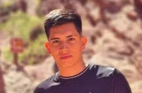

**TECNICO UNIVERSITARIO EN HIDROCARBUROS Y GEOCIENCIAS - ESTUDIANTE AVANZADO DE ING EN PERFORACIONES -TECNICO ELECTROMECANICO**

### Formación :

| Institución | Titulo | Año |
| --- | --- | --- |
| E.E.T N°3.136 “VESPUCIO” | TECNICO ELECTROMECANICO | 2.012-2.017 |
| UNIVERSIDAD SIGLO XXI | TECNICO UNIVERSITARIO EN HIDROCARBUROS Y GEOCIENCIAS | 2018-2021 |
| UNIVERSIDAD NACIONAL DE SALTA | INGENIERO EN PERFORACIONES | 2.018-2023 (3°AÑO) |
| UNIVERSIDAD NACIONAL DE ROSARIO | LICENCIATURA EN PETROLEO Y GAS | 2.024 (CURSANDO) |

### Experiencia Laboral :

- Ayudante de taller

### Sobre mi :

##### SOY UNA PERSONA PROACTIVA CAPAZ DE TRABAJAR BAJO PRESIÓN RESOLVIENDO PROBLEMAS EN EQUIPO E INDEPENDIENTEMENTE.DURANTE MI FORMACIÓN ACADEMICA ADQUIRÍ CONOCIMIENTOS RELACIONADOS CON LA ACTIVIDAD PETROLERA (PERFORACIÓN Y PRODUCCIÓN) , MINERA , MECANICA Y GEOLOGICA. MI OBJETIVO ES FORMAR PARTE DE UNA EMPRESA DONDE PUEDA PONER EN PRACTICA TODOS MIS CONOCIMIENTOS , QUE ME BRINDE LA OPORTUNIDAD DE ALCANZAR MIS METAS Y DE CRECER EN EL AREA LABORAL , PERSONAL E INTELECTUAL.

### Contacto :

- **Correo** : lucianoleguizamon60@gmail.com
- **Celular** : *+5493873302872*
- **Linkedin** : https://www.linkedin.com/in/luciano-leguizamon-domene-59201918b/

### Datos :

- **Fecha de Nacimiento** : 09/01/1999
- **Lugar** : Tartagal - Salta
- **DNI**: 41.487.375
- **CUIL** : 20-41487375-9
- **Estado Civil** : soltero
- **Edad** : 25 Años

### Cursos y Capacitaciones

- OPERARIO EN CONTROL DE SOLIDOS Y FLUIDOS DE PERFORACION
- OPERARIO EN PERFORACION, TERMINACION Y PRODUCCION DE POZOS DE PETROLEO Y GAS
- INYECCIONISTA EN FLUIDOS DE PERFORACION
- WORKOVER Y COMPLEMENTACION DE POZOS PETROLEROS
- MECANICO EN MOTORES DIESEL
- SEMINARIO SOBRE FRACTURA Y TERMINACION DE POZOS EN VACA MUERTA
- CEMENTACIÓN PRIMARIA Y CORRECTIVA
- WELL CONTROL
- JORNADA DE PERFORACIÓN
- JORNADA MINERA

### Conocimientos :

- Mecanica Basica
- Computación-Paquete Office (WORD-EXCEL-POWERPOINT

### Idiomas :

- Ingles (intermedio)
- Español (Nativo)

### *LICENCIA NACIONAL DE CONDUCIR - CATEGORIA E1*